# Week 07

Taylor Riley(mailto:striley@uw.edu)

2021-02-19 12:00

# 1 Study Overview

The National Longitudinal Study of Adolescent to Adult Health (Add Health) is a longitudinal study of a nationally representative sample of over 20,000 adolescents who were in grades 7-12 during the 1994-95 school year, and have been followed for five waves to date (https://addhealth.cpc.unc.edu/). This data is from the Add Health Wave 1 data set.

We will specifically explore poor appetite and depression among adolescents assigned female or male at birth.

# 2 Descriptive data

Table 2.1: Distribution of sex assigned at birth

Sex assigned at bith

n

%

1. Male

3147

48.39

2. Female

3356

51.60

6. Refused

1

0.02

Table 2.1: Distribution of reported poor appetite in the past week

Reported frequency of poor appetite

n

%

0. Never/rarely

4192

64.45

1. Sometimes

1744

26.81

2. A lot of the time

410

6.30

3. Most/all of the time

141

2.17

6. Refused

6

0.09

8. Don’t know

11

0.17

Table 2.1: Distribution of reported depression in the past week

Reported frequency of feeling depressed

n

%

0. Never/rarely

3994

61.41

1. Sometimes

1853

28.49

2. A lot of the time

444

6.83

3. Most/all of the time

193

2.97

6. Refused

8

0.12

8. Don’t know

12

0.18

Table 2.1: Reported poor appetite in the past week by sex assigned at birth

Male

Female

n

%

n

%

0. Never/rarely

2261

72.05

1931

57.66

1. Sometimes

707

22.53

1037

30.96

2. A lot of the time

126

4.02

284

8.48

3. Most/all of the time

44

1.40

97

2.90

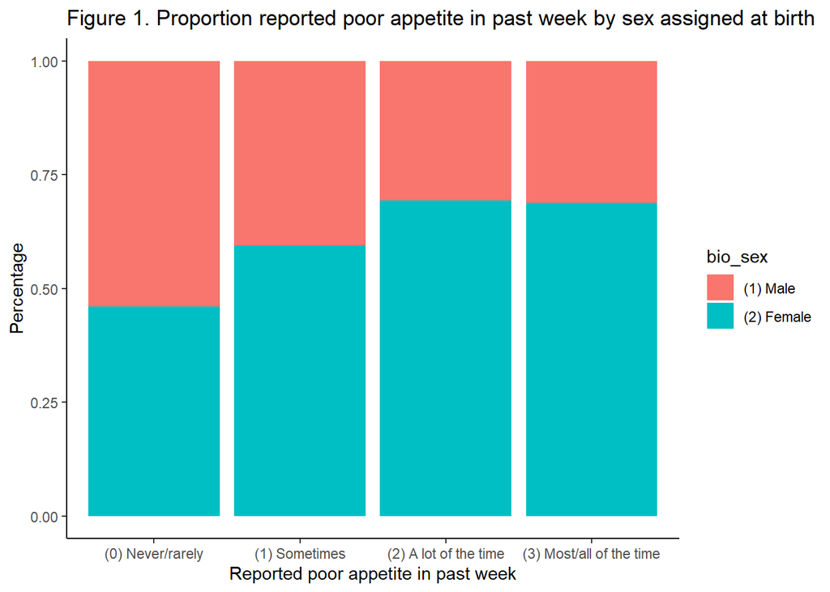

# 3 Code Appendix

```r
### -----------------------------------------------------------
# Set up
library(tidyverse)
library(magrittr)
library(kableExtra)
library(stargazer)
library(pander)
library(psych)
library(readstata13)
library(knitr)
library(animation)
library(bookdown)
library(rmarkdown)


# Load data
data <- readstata13::read.dta13("../data/AHwave1_v1.dta")



### -----------------------------------------------------------
###

# Create new dataframe
data_new <- data %>%
  select(aid, bio_sex, h1fs2, h1fs6)


# h1fs2 - You didn’t feel like eating, your appetite was poor.
table(data$h1fs2)
# h1fs6 - You felt depressed.
table(data$h1fs6)


# Set columns to factors
data_new$bio_sex <- as.factor(data_new$bio_sex)
data_new$poor_appetite <- as.factor(data_new$h1fs2)
data_new$depressed <- as.factor(data_new$h1fs6)

levels(data_new$poor_appetite)



### -----------------------------------------------------------
### Create some frequency tables
#a. Create a frequency table from each variable, using both counts and percentages.


# Tabulate by sex
tab_sex <- data_new %>%
  group_by(bio_sex) %>%
  summarise(n = n(), .groups = "drop_last") %>%
  mutate("%" = round(n / sum(n) * 100, 2))


# print the table with better printed names
kable(tab_sex, col.names = c("Sex assigned at bith", "n", "%"), caption = "Distribution of sex assigned at birth") %>%
    kable_styling(bootstrap_options =
                      c("striped", "hover", "condensed", "responsive"),
                  full_width = F,
                  position = "left")

# Tabulate by poor appetite
tab_poorapp <- data_new %>%
  group_by(poor_appetite) %>%
  summarise(n = n(), .groups = "drop_last") %>%
  mutate("%" = round(n / sum(n) * 100, 2))


# print the table with better printed names
kable(tab_poorapp, col.names = c("Reported frequency of poor appetite", "n", "%"), caption = "Distribution of reported poor appetite in the past week") %>%
    kable_styling(bootstrap_options =
                      c("striped", "hover", "condensed", "responsive"),
                  full_width = F,
                  position = "left")


# Tabulate by depression
tab_depressed <- data_new %>%
  group_by(depressed) %>%
  summarise(n = n(), .groups = "drop_last") %>%
  mutate("%" = round(n / sum(n) * 100, 2))


# print the table with better printed names
kable(tab_depressed, col.names = c("Reported frequency of feeling depressed", "n", "%"), caption = "Distribution of reported depression in the past week") %>%
    kable_styling(bootstrap_options =
                      c("striped", "hover", "condensed", "responsive"),
                  full_width = F,
                  position = "left")

# b.    Create a frequency table based on at least two variables, also with counts and percentages.


# tabulate poor appetite by sex
tab_app_male <- data_new %>%
   filter(poor_appetite != "(6) Refused" & poor_appetite != "(8) Don't know") %>%
    filter(bio_sex == "(1) Male") %>%
    group_by(poor_appetite) %>%
    summarise(n = n(), .groups = "drop_last") %>%
    mutate("%" = round(n / sum(n) * 100, 2))

tab_app_female <- data_new %>%
   filter(poor_appetite != "(6) Refused" & poor_appetite != "(8) Don't know") %>%
    filter(bio_sex == "(2) Female") %>%
    group_by(poor_appetite) %>%
    summarise(n = n(), .groups = "drop_last") %>%
    mutate("%" = round(n / sum(n) * 100, 2))


tab_app_sex <- cbind(tab_app_male, tab_app_female)
tab_app_sex[,4] <- NULL

# print the table with better printed names
kable(tab_app_sex, col.names = c("Self-reported Health", "n", "%", "n", "%"), caption = "Reported poor appetite in the past week by sex assigned at birth") %>%
    kable_styling(bootstrap_options =
                      c("striped", "hover", "condensed", "responsive"),
                  full_width = F,
                  position = "left") %>%
    add_header_above(c(" " = 1, "Male" = 2, "Female" = 2))


### Create at least one graph from data in the data frame.

#  Barchart
data_new %>%
  filter(bio_sex != "(6) Refused") %>%
  filter(poor_appetite != "(6) Refused" & poor_appetite != "(8) Don't know") %>%
ggplot(., aes(x=poor_appetite, fill=bio_sex)) +
  geom_bar(position="fill")+
  theme_classic()+
  ylab("Percentage")+
  xlab("Reported poor appetite in past week")+
  ggtitle("Figure 1. Proportion reported poor appetite in past week by sex assigned at birth")
```